# Analysis of published m5C data

This document will map data from m5C sites found in published data. The studies are detailed in the code below.

## Setting up the environment

```r
generalDatasets = 'C:/Users/chris/OneDrive/Documents/bccrc/projectsRepository/generalDatasets'
baseWorkspace = 'C:/Users/chris/OneDrive/Documents/bccrc/projectsWorkspace/sorensenLab/relatedToYbx1'
baseRepository = 'C:/Users/chris/OneDrive/Documents/bccrc/projectsRepository/sorensenLab/relatedToYbx1'
```

We need to call a source file that has some functions we will need. For simplicity and ease of tracking, I make a copy of this file in each directory that I will work in in order to be able to trace the exact one functions that are used, in case I change them and mistakenly don’t push it to GitHub.

```r
source(paste(baseWorkspace, '/sequencing20200629_publishedM5cDistributionData/userDefinedFunctions.R', sep = ''))
```

## Data processing

This data comes from multiple studies. We will compile the data from all of them below. I decided to convert all the results to hg38 in the end. I retrieved the chain file from here or [here](http://hgdownload.cse.ucsc.edu/goldenPath/hg19/liftOver/).

```r
#######################################################################################
###m5c site library preparation
###first we need to compile our set of m5c sites
####this first data set is from PMID: 32293435
m5c = read_csv(paste(baseRepository, '/sequencing20200629_publishedM5cDistributionData/m5c_HeLa_Schumann_hg38.csv', sep = ''))
m5cGrangePrep = m5c %>%
  mutate('chromosome' = Chrom) %>%
  filter(TranscriptType == 'protein_coding') %>%
  dplyr::select(chromosome, Start, End, Strand) %>%
  filter(!is.na(chromosome))
m5cSet1 = as_tibble(m5cGrange) %>%
  mutate('chromosome' = seqnames) %>%
  mutate('m5cSite' = end) %>%
  mutate('cells' = 'hela') %>%
  mutate('dataset' = 'schumann') %>%
  mutate('confidence' = 1) %>%
  dplyr::select(chromosome, strand, m5cSite, cells, dataset, confidence)


####next set is from T24 bladder cancer cells, PMID: 31358969
###from the paper: The m5C sites were called using meRanCall from meRanTK (false discovery rate < 0.01). Only sites with a coverage #depth ≥ 30, methylation #level ≥ 0.1 and methylated cytosine depth ≥ 5 were considered credible.
chain = import.chain('C:/Users/chris/OneDrive/Documents/bccrc/databases/HumanGenome_GTCh38.97/hg19ToHg38.over.chain')
m5c = read_csv(paste(baseRepository, '/sequencing20200629_publishedM5cDistributionData/m5c_T24_Chen_hg19.csv', sep = ''))
m5cGRangePrep = m5c %>%
  filter(`m5C Level` >= 0.1) %>%
  filter(Coverage >= 30) %>%
  filter(C_count >= 5)
m5cGrange = makeGRangesFromDataFrame(m5cGrangePrep)
m5cGrangeHg19 = unlist(liftOver(m5cGrange, chain), use.names = TRUE)
```

[output not shown]

```r
m5cSet2 = as_tibble(m5cGrangeHg19) %>%
  mutate('chromosome' = seqnames) %>%
  mutate('m5cSite' = end) %>%
  mutate('cells' = 't24') %>%
  mutate('dataset' = 'chen') %>%
  mutate('confidence' = 1) %>%
  dplyr::select(chromosome, strand, m5cSite, cells, dataset, confidence)



#####the next dataset is from HeLa cells, PMID: 28418038
m5c = read_csv(paste(baseRepository, '/sequencing20200629_publishedM5cDistributionData/m5c_HeLa_Yang_hg19.csv', sep = ''))
m5cGrangePrep = m5c %>%
  filter(`Gene Type` == 'mRNA') %>%
  filter(`Overall m5C Level` >= 0.1) %>%
  mutate(start = Position) %>%
  mutate(end = Position)
m5cGrange = makeGRangesFromDataFrame(m5cGrangePrep)
m5cGrangeHg19 = unlist(liftOver(m5cGrange, chain), use.names = TRUE)
```

```
Discarding unchained sequences: chrMT
```

```r
m5cSet3 = as_tibble(m5cGrangeHg19) %>%
  mutate('chromosome' = seqnames) %>%
  mutate('m5cSite' = end) %>%
  mutate('cells' = 'hela') %>%
  mutate('dataset' = 'yang') %>%
  mutate('confidence' = 1) %>%
  dplyr::select(chromosome, strand, m5cSite, cells, dataset, confidence)


#####the next dataset is from HEK293T cells, PMID: 31061524
m5c = read_csv(paste(baseRepository, '/sequencing20200629_publishedM5cDistributionData/m5c_HEK293T_Huang_hg19.csv', sep = ''))
m5cGrangePrep = m5c %>%
  filter(`if m5C site` == TRUE) %>%
  filter(`m5C level` >= 0.1) %>%
  filter(Coverage >= 30) %>%
  filter(!grepl('GL', Chromosome)) %>%
  mutate(start = Position) %>%
  mutate(end = Position) %>%
  mutate(chromosome = paste('chr',Chromosome, sep = '')) %>%
  dplyr::select(chromosome, start, end, Strand)
m5cGrange = makeGRangesFromDataFrame(m5cGrangePrep)
m5cGrangeHg19 = unlist(liftOver(m5cGrange, chain), use.names = TRUE)
```

```
Discarding unchained sequences: chrMT
```

```r
m5cSet4 = as_tibble(m5cGrangeHg19) %>%
  mutate('chromosome' = seqnames) %>%
  mutate('m5cSite' = end) %>%
  mutate('cells' = 'hek') %>%
  mutate('dataset' = 'huang') %>%
  mutate('confidence' = 1) %>%
  dplyr::select(chromosome, strand, m5cSite, cells, dataset, confidence)


######now combine the data
m5cData = rbind(m5cSet1, m5cSet2, m5cSet3, m5cSet4) %>%
  group_by(chromosome, strand, m5cSite) %>%
  summarize('numberOfIds' = sum(confidence))

####save the data
saveRDS(m5cData,
        paste(baseRepository, '/sequencing20200629_publishedM5cDistributionData/dataset_m5cSitesAllStudies.rds', sep = ''))
```

I want to find the location of all of these sites. We will need an external function for this. First I need to make a txdb for annotation.

```r
#######################################################################################
txdbEnsembl = makeTxDbFromEnsembl(organism = 'homo_sapiens',
                                  release = 99.37,
                                  server = 'useastdb.ensembl.org')
```

[output not shown]

Now prep the data for input to our function.

```r
#######################################################################################
m5cGrangePrep = m5cData %>%
  mutate(start = m5cSite) %>%
  mutate(end = m5cSite + 1) %>%
  dplyr::select(chromosome, strand, start, end)
##
m5cGrange = makeGRangesFromDataFrame(m5cGrangePrep)
```

Now we can run the function.

```r
#######################################################################################
m5cAnnotated = wavclusterPeakAnnotation(as_tibble(m5cGrange), txdbEnsembl, removeMito = TRUE)
```

```
Removing chromosome M hits.
Annotating fiveUTR hits.
Finding the longest transcript associated with each input gene in the txdb.
Core set of long transcripts assembled. Data returned.
Annotating the input txdb.
Filtering input txdb to keep only longest transcripts.
Returning the annotated txdb for alignment.
Annotation index for fiveUTR created.
Annotating fiveUTR overlap hits.
Annotation for fiveUTR complete.
Annotating CDS hits.
Annotating the input txdb.
Filtering input txdb to keep only longest transcripts.
Returning the annotated txdb for alignment.
Annotation index for CDS created.
Annotating CDS overlap hits.
Annotation for CDS complete.
Annotating threeUTR hits.
Annotating the input txdb.
Filtering input txdb to keep only longest transcripts.
Returning the annotated txdb for alignment.
Annotation index for threeUTR created.
Annotating threeUTR overlap hits.
Annotation for threeUTR complete.
Combining the data sets and performing the final calculations
Processing complete
```

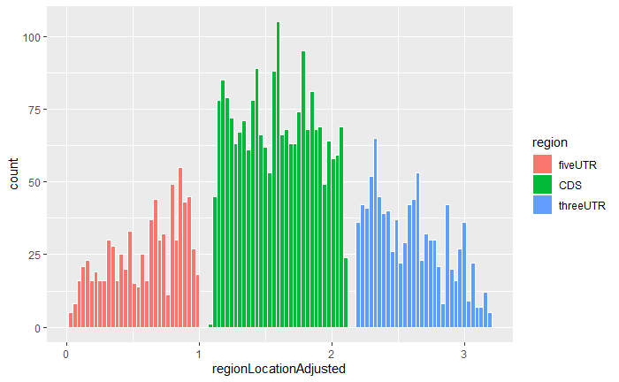

```r
ggplot(m5cAnnotated, aes(regionLocationAdjusted, fill = region)) +
  geom_histogram(bins = 100, color = 'white', size = 0.1)
```

[session information not shown]